# Лекция 0. RLMS-HSE: устройство данных

Блок 0. Данные и язык причинности

Карен Аванесян

Каузальный анализ в R на данных RLMS-HSE

# Зачем

## О чём этот курс

Курс отвечает на один вопрос: **как по наблюдательным данным оценить причинный эффект и не обмануть себя**.

- Формул минимум: потенциальные исходы, остальное — дизайн, код и интерпретация
- Каждое занятие: 20 минут «что это и в чём смысл» → 50 минут кода на RLMS → 20 минут «как ошибаются»
- Две сквозные линии, к которым мы возвращаемся разными методами:
  - **образование → зарплата**: OLS → мэтчинг → FE → IV → causal forest → чувствительность
  - **рождение ребёнка → занятость женщин**: event study → DiD → RD → IV

## Почему RLMS-HSE

- Единственная длинная **панель** по России: 1994–1996, 1998, 2000–2025
- Одни и те же люди опрашиваются каждый год → можно смотреть *изменения внутри человека*
- Занятость, зарплата, образование, семья, здоровье, курение, субъективное благополучие — всё в одном файле
- Почти каждый метод курса можно показать на этих данных

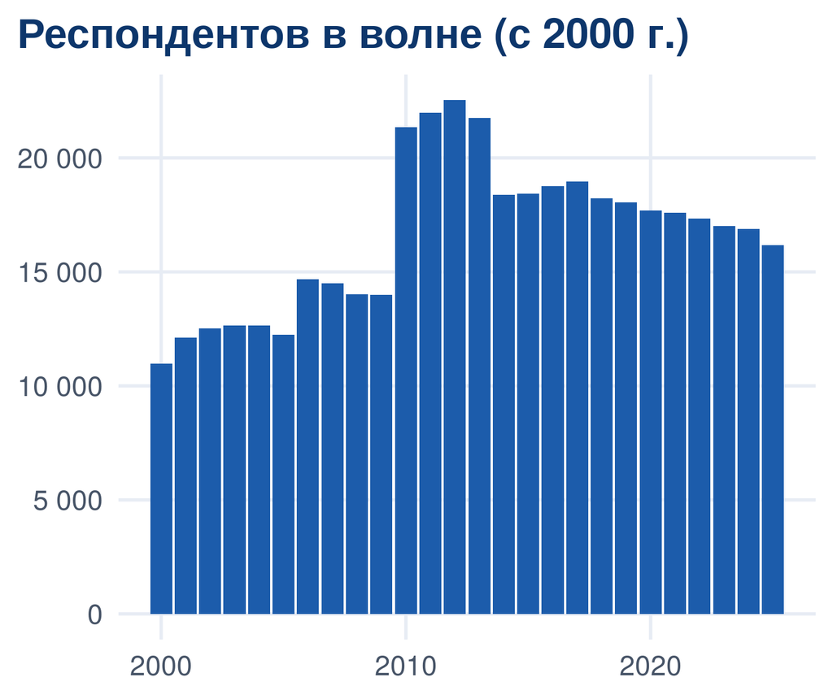

## План занятия

1. Как устроена выборка RLMS и что такое «волна»
2. Файлы, идентификаторы, веса, пропуски
3. Как читать кодбук и не перепутать коды
4. Учебная панель курса: что в ней есть
5. Первые дескриптивы и первая регрессия (пока без причинности)

# Идея

## Что такое RLMS-HSE

38 площадок (PSU) по всей стране

4–7 тыс. домохозяйств в волне

11–22 тыс. индивидов в волне

окт–дек когда идёт опрос

- **Р**оссийский **м**ониторинг **э**кономического положения и **з**доровья населения НИУ ВШЭ (RLMS-HSE)
- Проводят НИУ ВШЭ и ООО «Демоскоп» при участии Университета Северной Каролины и Института социологии РАН
- Многоступенчатая вероятностная выборка домохозяйств: площадки — первичные единицы отбора
- Данные бесплатны для исследователей после регистрации на [сайте проекта](https://www.hse.ru/rlms/); **передавать файлы третьим лицам нельзя**

## Панель: одни и те же люди из года в год

- Домохозяйство попало в выборку → его опрашивают каждую волну, **пока оно живёт по тому же адресу**
- С 2010 г. за переехавшими внутри площадки **следуют** (поэтому в 2010 г. выборка выросла)
- Люди уходят (отказ, переезд, смерть) и возвращаются → панель **несбалансированная**
- Около 10–15 % респондентов не попадают в следующую волну

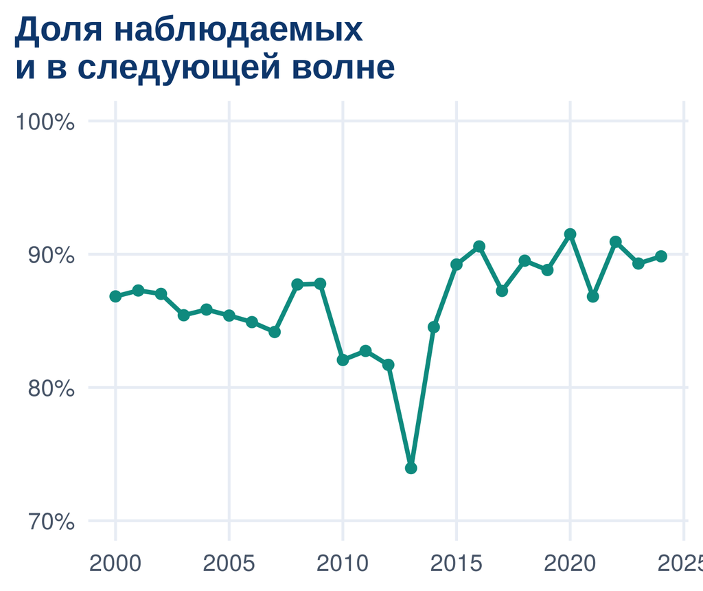

## Файлы, которые вы скачаете

| Файл | Что внутри | Когда нужен |
| --- | --- | --- |
| **Индивидуальный** (`RLMS_IND_1994_2025`) | одна строка = человек × волна; взрослый и детский вопросники | всегда — это наш основной файл |
| **Домохозяйственный** (`RLMS_HH_…`) | одна строка = домохозяйство × волна: доходы, расходы, состав, жильё | доход семьи, бедность |
| «Идентификационные номера родственников» | кто кому в домохозяйстве супруг, родитель, ребёнок | дети, event study, IV по полу детей |
| Кодбуки (PDF, xlsx) | вопросы, коды, метки, в каких волнах задавался вопрос | каждый раз, когда берёте новую переменную |

Объединённый индивидуальный файл — **7–15 ГБ** в формате `.dta`/`.sav` и 4 000+ столбцов. Целиком в память его читать не нужно.

## Четыре идентификатора

| Переменная | Смысл | Уникальна… |
| --- | --- | --- |
| `id_w` | номер волны (9 = 2000, …, 34 = 2025) | — |
| `idind` | **сквозной** номер человека | в паре с `id_w` |
| `id_i` | номер человека *внутри* волны | только внутри волны |
| `id_h` | номер домохозяйства *внутри* волны | только внутри волны |

- Панель строится по `idind + year`; дубликатов `idind × year` быть не должно
- К домохозяйственному файлу присоединяемся по `id_w + id_h`
- `region` — это **площадка** (PSU), а не субъект федерации: «Краснодар» и «Краснодарский край, Кущёвский район» — две разные площадки

## Веса: `inwgt`

- Пост-стратификационный вес индивида по Росстату: выравнивает выборку по полу, возрасту, типу поселения
- Определён только для **репрезентативной части** выборки; у остальных `inwgt = 0`

Взвешивать или нет?

описание

### Статистика «по России»

**Да** — взвешиваем.

регрессия

### С контролями на пол, возраст, поселение

Обычно **нет**: веса мало что меняют, но раздувают стандартные ошибки.

честный ответ

### Сравнить оба варианта

Оценки с весами и без (Solon, Haider, Wooldridge 2015).

## Пропуски и коды-«сентинелы»

В RLMS «нет ответа» — не `NA`, а **огромные числа**:

| Код | Смысл |
| --- | --- |
| `99999997` | затрудняюсь ответить |
| `99999998` | отказ от ответа |
| `99999999` | нет ответа |
| `88888888` | вопрос не задавался / не применимо |

Если не вычистить коды, средняя зарплата по стране получится **3 миллиона рублей**. Проверим на следующем слайде.

## Как читать кодбук

- Имя переменной = номер вопроса в анкете: `j10` — раздел J («Работа»), вопрос 10: «Сколько денег в течение последних 30 дней Вы получили по основному месту работы?»
- Разделы: `h` — паспортичка, `i` — миграция, `j` — работа и образование, `l`/`m` — здоровье, `n` — репродуктивное поведение
- Служебные переменные без номера: `age`, `diplom`, `educ`, `marst`, `status`, `occup08`, `inwgt`
- Кодбук говорит, **в каких волнах** вопрос задавался: Большая пятёрка — 2016, 2019, 2020, 2023–2025; ЕГЭ — с 2009-го

## Никогда не угадывайте коды

Переменная `status` — тип населённого пункта. Интуиция подсказывает «1 = село, 4 = областной центр». Кодбук говорит обратное:

| код | метка |
| --- | --- |
| 1 | Областной центр |
| 2 | Город |
| 3 | ПГТ |
| 4 | Село |

Ошибка в одной строке перекодировки незаметна в регрессии — знак коэффициента при «селе» просто поменяется. Всегда печатайте `attr(x, "labels")` или таблицу `count(as_factor(x))`.

# Код

## Читаем сырые данные: только нужные столбцы

Так выглядит извлечение из 7-гигабайтного файла (`causal-r/R/01_extract_rlms.R`):

```r
library(haven)
ind <- read_dta(file.path(rlms_path, "RLMS_IND_1994_2025_rus.dta"),
                col_select = c("id_w", "year", "idind", "id_h", "age", "h5",
                               "diplom", "j1", "j10", "m71", "inwgt"))
attr(ind$j1, "label")           # текст вопроса
attr(ind$j1, "labels")          # метки значений
ind |> count(j1 = as_factor(j1))
```

- `col_select` читает с диска только нужные колонки: 7 ГБ → секунды
- `haven` сохраняет метки; `as_factor()` превращает коды в русские категории
- `zap_labels()` снимает метки, когда нужны чистые числа

## Сентинелы: до и после

```r
raw <- readRDS(here::here("causal-r/data/rlms_panel_raw.rds"))
summary(raw$j10)                                   # зарплата за 30 дней, как в файле
```

```
    Min.  1st Qu.   Median     Mean  3rd Qu.     Max.     NA's
      10     8000    17000  3191587    30000 99999999   248939
```

```r
na_sentinel <- function(x, floor = 88888888) ifelse(!is.na(x) & x >= floor, NA, x)
summary(na_sentinel(raw$j10))
```

```
   Min. 1st Qu.  Median    Mean 3rd Qu.    Max.    NA's
     10    7500   16200   23070   30000 3236000  254725
```

Одна функция `na_sentinel()` применяется ко **всем** содержательным переменным до любых расчётов. В учебной панели это уже сделано.

## Учебная панель курса

```r
dim(rlms); n_distinct(rlms$idind); range(rlms$year)
```

```
[1] 431506    119
```

```
[1] 57042
```

```
[1] 2000 2025
```

```r
rlms |> select(idind, year, sex, age, educ_level, employed, wage_real, smokes) |>
  slice_head(n = 6)
```

| idind | year | sex | age | educ_level | employed | wage_real | smokes |
| --- | --- | --- | --- | --- | --- | --- | --- |
| 1 | 2000 | Женщины | 27 | Высшее | 1 | 6026 | 0 |
| 1 | 2001 | Женщины | 28 | Высшее | 1 | 12636 | 0 |
| 1 | 2002 | Женщины | 29 | Высшее | 1 | 14921 | 0 |
| 1 | 2003 | Женщины | 30 | Высшее | 1 | 57024 | 0 |
| 1 | 2005 | Женщины | 32 | Высшее | 1 | 27952 | 0 |
| 1 | 2006 | Женщины | 33 | Высшее | 1 | 47343 | 0 |

## Что в панели (1/2)

| Группа | Переменные |
| --- | --- |
| Идентификаторы и дизайн | `idind`, `id_h`, `year`, `psu`, `site`, `subject`, `settlement`, `urban`, `inwgt`, `repres` |
| Демография | `sex`, `female`, `age`, `birth_year`, `marital`, `married`, `has_children`, `n_children` |
| Образование | `educ_level`, `higher_ed`, `years_educ`, `school_type`, `ege_taken`, `in_university`, `training_12m` |
| Занятость | `employed`, `work_status`, `wage`, `wage_real` (руб. 2024), `log_wage`, `hours_week`, `official`, `state_owned`, `industry`, `occup_group`, `tenure`, `experience` |
| Поиск работы | `want_job`, `searched`, `search_months`, `registered_unemp`, `unemp_benefit` |

## Что в панели (2/2)

Полный словарь — в `causal-r/data/variable_labels.csv` и в `02_recode_panel.R`

| Группа | Переменные |
| --- | --- |
| Пенсия | `pension`, `pension_age`, `pension_year` |
| Здоровье и поведение | `health_self`, `health_score`, `good_health`, `disabled`, `smokes`, `drinks`, `drinks_weekly`, `bmi`, `any_chronic` |
| Субъективное | `life_sat`, `wealth_ladder`, `satisf_job`, `worry_job_loss`, `internet` |
| Большая пятёрка | `O`, `C`, `E`, `A`, `ES` — z-баллы, база 2016 (волны 2016, 2019, 2020, 2023–2025) |
| Дети по ростеру | `n_children_linked`, `first_birth_year`, `child1_sex`, `child2_sex`, `same_sex_first2`, `event_time_first_birth` |
| Панель | `n_waves`, `first_year`, `last_year` |

## Сколько волн на человека

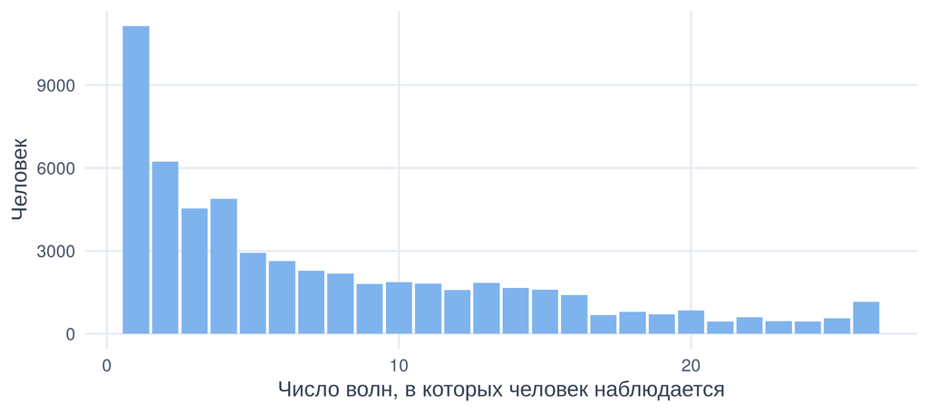

```r
rlms |> distinct(idind, n_waves) |>
  ggplot(aes(n_waves)) + geom_bar(fill = pal["lavender"]) +
  labs(x = "Число волн, в которых человек наблюдается", y = "Человек")
```

## Внутри человека: лаги и переходы

Главная сила панели — сравнивать человека **с самим собой**. Для этого сортируем по `idind, year` и берём лаг:

```r
trans <- rlms |>
  filter(age >= 25, age <= 55) |>
  arrange(idind, year) |>
  group_by(idind) |>
  mutate(employed_prev = lag(employed), year_prev = lag(year)) |>
  ungroup() |>
  filter(year_prev == year - 1)                      # только соседние волны

trans |> count(employed_prev, employed) |>
  group_by(employed_prev) |> mutate(share = round(n / sum(n), 3))
```

| employed_prev | employed | n | share |
| --- | --- | --- | --- |
| 0 | 0 | 23274 | 0.759 |
| 0 | 1 | 7404 | 0.241 |
| 1 | 0 | 7522 | 0.061 |
| 1 | 1 | 116128 | 0.939 |

Проверяйте, что лаг — именно **предыдущий год**, а не «предыдущая волна, когда человек встретился» (между ними может быть 5 лет).

## Веса: сравниваем с ними и без

- Результат
- Код

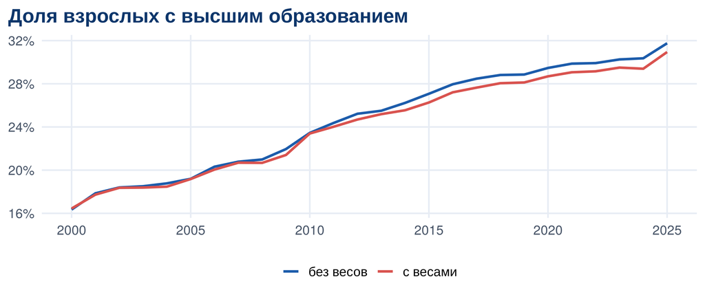

```r
w <- rlms |> filter(adult == 1) |>
  group_by(year) |>
  summarise(`без весов` = mean(higher_ed, na.rm = TRUE),
            `с весами` = weighted.mean(higher_ed, inwgt, na.rm = TRUE)) |>
  pivot_longer(-year, names_to = "оценка", values_to = "share")
```

## Номинальные и реальные рубли

```r
rlms |> filter(employed == 1, age >= 18, age <= 64) |>
  group_by(year) |>
  summarise(`номинальная` = median(wage, na.rm = TRUE),
            `в ценах 2024` = median(wage_real, na.rm = TRUE)) |>
  pivot_longer(-year, names_to = "зарплата", values_to = "rub") |>
  ggplot(aes(year, rub, colour = зарплата)) + geom_line(linewidth = 1.1) +
  scale_y_continuous(labels = scales::label_number(big.mark = " ")) +
  labs(x = NULL, y = "руб./мес., медиана", colour = NULL)
```

`wage_real` = `wage` / ИПЦ(год) × 100, база 2024 г. (таблица в `R/cpi_russia.R`). Для регрессий чаще достаточно `log(wage)` + фиксированные эффекты года.

## Номинальные и реальные рубли

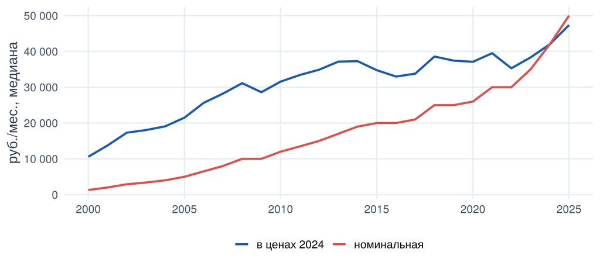

## Разрыв в зарплатах по образованию

```r
rlms |> filter(employed == 1, age >= 25, age <= 60, !is.na(educ_level)) |>
  group_by(year, educ_level) |>
  summarise(lw = mean(log_wage, na.rm = TRUE), .groups = "drop") |>
  ggplot(aes(year, lw, colour = educ_level)) + geom_line(linewidth = 1.1) +
  labs(x = NULL, y = "средний log(реальной зарплаты)", colour = NULL)
```

## Разрыв в зарплатах по образованию

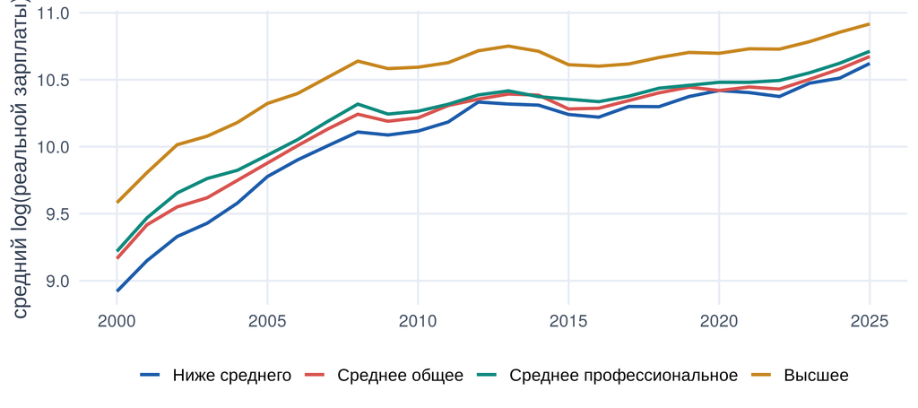

## Первая регрессия — пока без причинности

```r
m0 <- feols(log_wage ~ higher_ed + female + age + I(age^2) | year,
            data = adults |> filter(employed == 1), cluster = ~psu)
etable(m0, headers = "log(зарплата)")
```

|  | m0 |
| --- | --- |
|  | log(зарплата) |
| Dependent Var.: | log_wage |
| higher_ed | 0.364*** (0.032) |
| female | -0.433*** (0.013) |
| age | 0.047*** (0.004) |
| I(I(age^2)) | -0.0006*** (4.98e-5) |
| _______________ | ____________________ |
| S.E.: Clustered | by: psu |
| Observations | 171,729 |
| R2 | 0.27 |

## Как читать вывод `etable()`

- Вывод R
- С пояснениями

```
                                  m0
                log(зарплата)
Dependent Var.:             log_wage

higher_ed           0.364*** (0.032)
female             -0.433*** (0.013)
age                 0.047*** (0.004)
I(I(age^2))     -0.0006*** (4.98e-5)
_______________ ____________________
S.E.: Clustered              by: psu
Observations                 171,729
R2                              0.27
---
Signif. codes: 0 '***' 0.001 '**' 0.01 '*' 0.05 '.' 0.1 ' ' 1
```

1 · шапка

Имя модели (`m0`), подпись из `headers` и **Dependent Var.** — зависимая переменная. Первое, что проверяем: это `log_wage`, а не `wage`

2 · число и скобки

Число — оценка, **в скобках — стандартная ошибка** (не t и не p). Звёзды — порог p-value из строки `Signif. codes`. Единицы — лог-пункты: 0.364 ≈ +44 % к зарплате

3 · `I(I(age^2))`

Так `fixest` называет `I(age^2)`. Коэффициент крошечный, потому что $age^2$ огромен; его ошибка — в экспоненциальной записи (`4.98e-5` = 0.0000498). Читается только вместе с `age`: пик зарплаты в 39 лет

4 · S.E.

Тип ошибок: **Clustered by psu** — 38 кластеров. Тип ошибок меняет скобки и звёзды, но **не** коэффициенты

5 · N и R2

171 729 наблюдений из 189 317 строк: `fixest` молча выбросил строки с `NA`. R2 включает эффекты года — их строку курс скрывает (`drop.section = "fixef"`)

6 · сигналы беды

N намного меньше ожидаемого; `S.E.: IID` у панели или кластерной выборки; |коэффициент| > 1 у дамми при логарифме (×2.7 к зарплате) — проверьте единицы и кодировку

## Как читать этот коэффициент

Коэффициент ≈ 0.36: у людей с высшим образованием зарплата выше примерно на 44 % *при прочих равных из этой формулы* (пол, возраст, год).

- Это **описание условного среднего**, а не эффект образования
- Люди с дипломом и без него различаются ещё сотней способов, которых в формуле нет: способности, семья, место жительства, мотивация
- Вопрос курса: при каких допущениях и каким дизайном эту цифру можно превратить в **эффект** — и что получится (спойлер: заметно меньше)

## Кластеризация: почему `psu`

- Выборка строится по 38 площадкам → наблюдения внутри площадки похожи (рынок труда, цены)
- Обычные стандартные ошибки предполагают независимость → **занижены**

срезы

### `cluster = ~psu`

Минимальный честный вариант: зависимость внутри площадки.

панель

### `cluster = ~idind`

Один человек наблюдается много раз. `fixest` делает это одной опцией; по умолчанию в курсе `panel.id = ~idind + year`.

# Как ошибаются

## Семь типичных ошибок с RLMS

1. Не вычистили коды `99999997–99999999` → «средняя зарплата 3 млн»
2. Приняли `region` за субъект федерации (это площадка)
3. Присоединили домохозяйственный файл только по `id_h`, без `id_w`
4. Сравнили номинальные рубли 2005 и 2024 годов
5. Считали «занятыми» только `j1 == 1`, забыв про отпуск и декрет (`j1 ∈ 2:4`)
6. Взяли лаг «по предыдущей строке», а не по предыдущему году
7. Угадали коды (`status == 1` — это **областной центр**, а не село)

## Чек-лист перед любой моделью

- Какие волны содержат нужный вопрос? (кодбук)
- Сентинелы → `NA`
- Нет дубликатов `idind × year`
- Выборка: возраст, занятость, репрезентативная часть — **явно** записана в коде
- Деньги — в сопоставимых ценах или с фиксированными эффектами года
- Стандартные ошибки кластеризованы (`psu` или `idind`)

# Мини-задача

## Задание к следующему занятию

1. Постройте для **своей площадки** (`site`) ряд медианной реальной зарплаты 2000–2025 и сравните с общероссийским
2. Посчитайте долю респондентов 2019 г., которых нет в 2020 г., отдельно для мужчин и женщин и для возрастных групп. Кто «теряется» чаще?
3. Найдите в кодбуке переменную о том, пользуется ли человек интернетом, и выясните, в каких волнах она есть
4. Воспроизведите регрессию с предыдущего слайда с весами `inwgt` (аргумент `weights = ~inwgt`). Что изменилось?

# Литература

## Что прочитать

- Козырева П., Косолапов М., Попкин Б. (2016). Data Resource Profile: RLMS-HSE. *International Journal of Epidemiology*, 45(2), 395–401
- Документация и кодбуки RLMS-HSE: [hse.ru/rlms](https://www.hse.ru/rlms/)
- Solon G., Haider S., Wooldridge J. (2015). What Are We Weighting For? *Journal of Human Resources*, 50(2), 301–316
- Huntington-Klein N. *The Effect*, гл. 3–4 — описательные данные и панели
- Пакеты: [`haven`](https://haven.tidyverse.org/), [`fixest`](https://lrberge.github.io/fixest/), [`modelsummary`](https://modelsummary.com/)

Каузальный анализ в R · RLMS-HSE · К. Аванесян

← К программе курса